# Loading Expedition Data

A. Warmack

9/4/2018

# Summary

# Combining Log Files

```r
dat_folder <- "../raw_data/expedition_data"

#get the list of log files
dat_files <- list.files(dat_folder, full.names = TRUE)

#Read the csv files
exp_raw <- lapply(dat_files, read.csv, stringsAsFactors=FALSE)
exp_raw <- do.call(rbind, exp_raw)
```

## Cleaning Up The Data

### Removing Unneeded Columns

The Expedition data contains many columns that do not contain any data.

```r
#Find columns where all is NA
allna <- which(apply(exp_raw, 2, function(x) all(is.na(x))))

#remove those columns
expdat <- exp_raw %>% select(-allna)
```

### Convert the time from Excel Format

```r
expdat$time <- as.POSIXct((expdat$Utc) * (60*60*24), origin = "1899-12-30", tz = "America/Detroit")
```

### Select the useful columns

- *time*
- *Bsp* = Boatspeed thru water
- *Awa* = Apparent Wind Angle (Degrees Relative to boat)
- *Aws* = Apparent Wind Speed (in knots)
- *Twa* = True Wind Angle (Degrees Relative to boat)
- *Tws* = True Wind Speed (in knots)
- *Twd* = True Wind Direction (Bearing Relative to the Earth)
- *Lat/Lon* = Position
- *Cog* = Course Over Ground (Bearing in Degrees)
- *Sog* = Speed Over Ground (in Knots)

```r
#Select only needed columns
expdat <- expdat %>% select(time, Bsp, Awa, Aws, Twa, Tws, Twd, Lat, Lon, Cog, Sog)

#change names to lowercase for easier handling
names(expdat) <- tolower(names(expdat))

str(expdat)
```

```
## 'data.frame':    86330 obs. of  11 variables:
##  $ time: POSIXct, format: "2018-07-14 05:45:12" "2018-07-14 05:45:15" ...
##  $ bsp : num  NA NA NA NA NA NA NA NA NA NA ...
##  $ awa : num  NA NA NA NA NA NA NA NA NA NA ...
##  $ aws : num  NA NA NA NA NA NA NA NA NA NA ...
##  $ twa : num  NA NA NA NA NA NA NA NA NA NA ...
##  $ tws : num  NA NA NA NA NA NA NA NA NA NA ...
##  $ twd : num  NA NA NA NA NA NA NA NA NA NA ...
##  $ lat : num  NA NA NA NA NA NA NA NA NA NA ...
##  $ lon : num  NA NA NA NA NA NA NA NA NA NA ...
##  $ cog : num  NA NA NA NA NA NA NA NA NA NA ...
##  $ sog : num  NA NA NA NA NA NA NA NA NA NA ...
```

### Remove Data from before and after the race

```r
#remove pre-start and post-finsih
expdat <- expdat %>% dplyr::filter(time > as.POSIXct("2018-7-14 16:00:00"))

expdat <- expdat %>% dplyr::filter(time < as.POSIXct("2018-07-17"))

head(expdat$time)
```

```
## [1] "2018-07-14 16:11:45 EDT" "2018-07-14 16:11:46 EDT"
## [3] "2018-07-14 16:11:47 EDT" "2018-07-14 16:11:48 EDT"
## [5] "2018-07-14 16:11:49 EDT" "2018-07-14 16:11:50 EDT"
```

## Data Exploration

### Basic Stats

```r
summary(expdat)
```

```
##       time                          bsp               awa
##  Min.   :2018-07-14 16:11:45   Min.   :  0.000   Min.   :-179.50
##  1st Qu.:2018-07-15 04:52:42   1st Qu.:  1.780   1st Qu.: -88.50
##  Median :2018-07-15 12:35:15   Median :  2.880   Median : -39.50
##  Mean   :2018-07-15 15:04:27   Mean   :  3.011   Mean   : -11.97
##  3rd Qu.:2018-07-15 23:55:56   3rd Qu.:  4.370   3rd Qu.:  60.00
##  Max.   :2018-07-16 20:26:09   Max.   :655.350   Max.   : 180.00
##                                NA's   :17306     NA's   :14508
##       aws              twa                tws              twd
##  Min.   : 0.000   Min.   : -180.00   Min.   : 0.000   Min.   :  -47.0
##  1st Qu.: 3.300   1st Qu.: -127.10   1st Qu.: 3.390   1st Qu.:  102.7
##  Median : 4.600   Median :  -74.00   Median : 5.030   Median :  171.8
##  Mean   : 4.943   Mean   :  -13.84   Mean   : 5.662   Mean   :  186.0
##  3rd Qu.: 6.000   3rd Qu.:  105.90   3rd Qu.: 7.400   3rd Qu.:  258.1
##  Max.   :62.400   Max.   :43296.60   Max.   :61.980   Max.   :43297.2
##  NA's   :14508    NA's   :14485      NA's   :14484    NA's   :20638
##       lat             lon              cog              sog
##  Min.   :43.07   Min.   :-83.84   Min.   :-35.99   Min.   :  0.000
##  1st Qu.:43.37   1st Qu.:-82.85   1st Qu.: 38.70   1st Qu.:  2.400
##  Median :43.89   Median :-82.56   Median :323.80   Median :  3.440
##  Mean   :44.09   Mean   :-82.75   Mean   :239.28   Mean   :  3.545
##  3rd Qu.:44.59   3rd Qu.:-82.47   3rd Qu.:347.90   3rd Qu.:  4.700
##  Max.   :45.49   Max.   :214.29   Max.   :360.00   Max.   :211.230
##  NA's   :34833   NA's   :34831    NA's   :24387    NA's   :24388
```

We can see there is a large number of NA’s for most columns. The most important columns are apparent wind angle (awa), apparent wind speed (awa), boatspeed (bsp), and position (lat/lon). The remaining variables can be calculated from these values.

# where do we have AWS and AWA

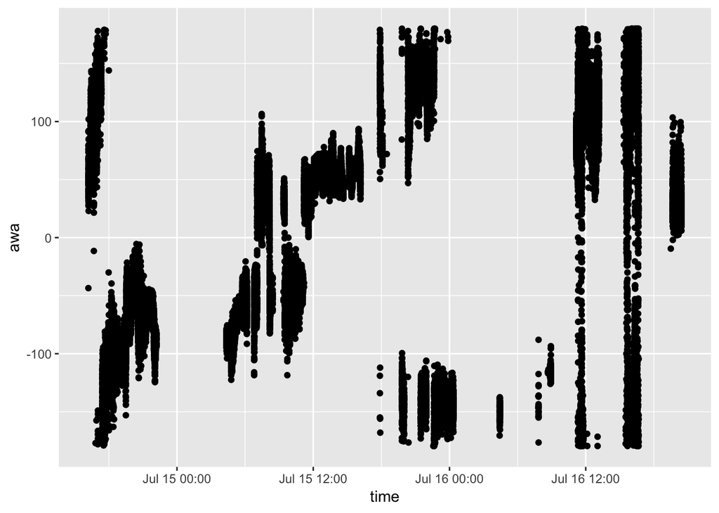

```r
library(ggplot2)

ggplot(expdat) + geom_point( aes(x=time, y=awa))
```

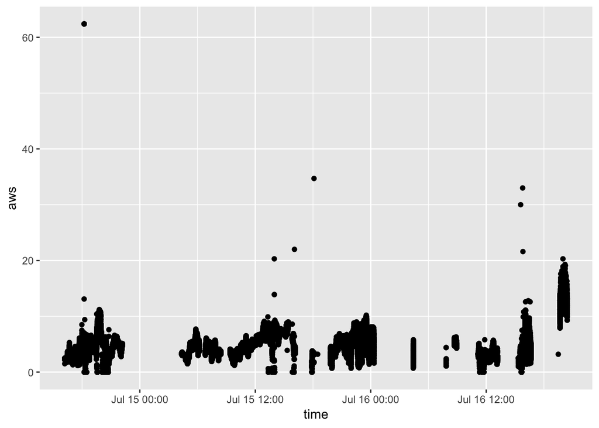

```r
ggplot(expdat) + geom_point(aes(x=time, y=aws))
```

We can see there are quite large chunks of data missing. These chunks are too large to interpolate over. We can also see some outlier data. We will handle these later. First, let’s remove the chunks of data without AWA & AWS data so that we can fill in blank data for other variables.

The Zoo package has a handy function for interpolating data. Thankfully, the na.approx function from the Zoo library has an argument to define the maximum gap to interpolate over.

```r
library(zoo)
```

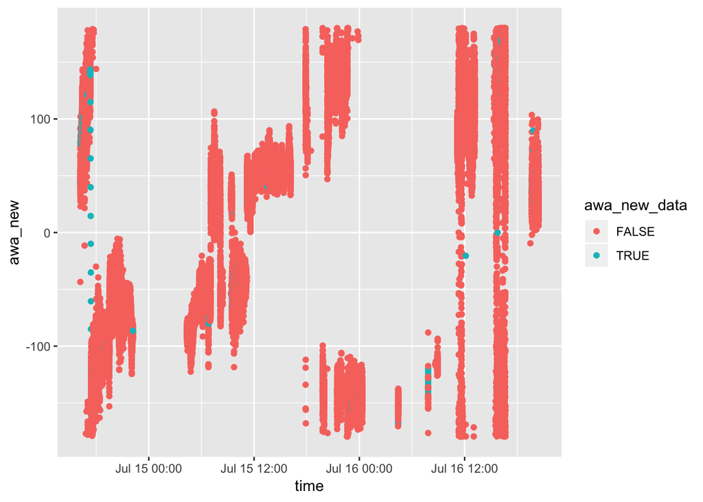

```r
awa_new <- na.approx(expdat$awa, x = expdat$time, maxgap = 30)
aws_new <- na.approx(expdat$aws, x = expdat$time, maxgap = 30)

#create a marker for the graph to show where the new data is created
awa_new_data <- is.na(expdat$awa) & !is.na(awa_new)
aws_new_data <- is.na(expdat$aws) & !is.na(aws_new)

#apply the new data to the data frame
expdat$awa <- awa_new
expdat$aws <- aws_new

testplotdf <- data.frame(time =expdat$time, awa_new, new_data = awa_new_data)

#plot AWA data
ggplot(testplotdf) + geom_point(aes(x=time, y=awa_new, color=awa_new_data))
```

Now that we’ve filled in some smaller gaps, lets remove the large gaps where either the AWA or AWS is missing.

```r
expdat <- expdat[!is.na(expdat$awa) & !is.na(expdat$aws), ]

summary(expdat)
```

```
##       time                          bsp               awa
##  Min.   :2018-07-14 16:11:45   Min.   :  0.000   Min.   :-179.50
##  1st Qu.:2018-07-14 21:52:52   1st Qu.:  1.780   1st Qu.: -88.50
##  Median :2018-07-15 12:05:19   Median :  2.880   Median : -39.50
##  Mean   :2018-07-15 13:48:28   Mean   :  3.011   Mean   : -11.93
##  3rd Qu.:2018-07-15 22:50:46   3rd Qu.:  4.370   3rd Qu.:  60.00
##  Max.   :2018-07-16 20:26:09   Max.   :655.350   Max.   : 180.00
##                                NA's   :3616
##       aws             twa                tws              twd
##  Min.   : 0.00   Min.   : -180.00   Min.   : 0.000   Min.   :-47.0
##  1st Qu.: 3.30   1st Qu.: -127.10   1st Qu.: 3.390   1st Qu.:102.7
##  Median : 4.60   Median :  -74.00   Median : 5.030   Median :171.8
##  Mean   : 4.94   Mean   :  -13.85   Mean   : 5.662   Mean   :185.3
##  3rd Qu.: 6.00   3rd Qu.:  105.90   3rd Qu.: 7.400   3rd Qu.:258.1
##  Max.   :62.40   Max.   :43296.60   Max.   :61.980   Max.   :360.0
##                  NA's   :798        NA's   :798      NA's   :6952
##       lat             lon              cog              sog
##  Min.   :43.07   Min.   :-83.84   Min.   :-35.99   Min.   :0.000
##  1st Qu.:43.37   1st Qu.:-82.85   1st Qu.: 38.70   1st Qu.:2.400
##  Median :43.89   Median :-82.56   Median :323.80   Median :3.440
##  Mean   :44.09   Mean   :-82.75   Mean   :239.27   Mean   :3.541
##  3rd Qu.:44.59   3rd Qu.:-82.47   3rd Qu.:347.90   3rd Qu.:4.700
##  Max.   :45.49   Max.   :214.29   Max.   :360.00   Max.   :6.850
##  NA's   :21143   NA's   :21142    NA's   :10698    NA's   :10700
```